# MOC PCSF Pipeline

2023-11-16

## Description

The genes in this pipeline are those identified to be differentially expressed (DE) in stage_I, stage_II, stage_III and stage_IV samples. Run with interaction data from DE gene list in STRING. In this run, no cutoff is used for DE genes i.e. -3 to 3 (used all DE genes).

See end of doc for gene subset summary

**Show Kylie raw data treatment**

```r
sample_info <- read.csv("data/All survival_CN_Aug18.csv")
sample_info <- subset(sample_info, select = c("GAMUT_ID", "Grade", "Stage"))

kylie_counts <- read.csv("data/analysis_set_raw_counts.csv", row.names = 1)

# Extract column names
column_names <- colnames(kylie_counts)

# Remove "GAMuT_" part from column names
gamut_ids <- sub("^GAMuT_", "", column_names)


# create list of stage ids
stage_I <- c("I","IA","IB","IC")
stage_II <- c("II", "IIA", "IIB", "IIC")
stage_III <- c("III", "IIIA", "IIIB", "IIIC", "IIIc")
stage_IV <- c("IV")
stage_ids <- list(stage_I, stage_II, stage_III, stage_IV)

# common GAMuT IDs between sample_info and kylie_counts
matching_ids <- intersect(gamut_ids, sample_info$GAMUT_ID)

stage_df <- list()

for (stage in stage_ids) {
  # sanity check
  print(stage)
  # retrieve GAMuT ID for the stage
  stage_id <- sample_info[sample_info$Stage %in% stage, 1]
  # common GAMuT IDs between stage and matching_ids
  matching_stage_id <- intersect(matching_ids, stage_id)
  # subset the kylie_counts df based on the IDs from matching_stage_id
  subset_stage_counts <- kylie_counts[, paste0("GAMuT_", matching_stage_id)]
  # add it to the df list
  stage_df <- c(stage_df, list(subset_stage_counts))
}

# retrieve each df from the list and save a separate variable
stage_I <- stage_df[[1]]
stage_II <- stage_df[[2]]
stage_III <- stage_df[[3]]
stage_IV <- as.data.frame(stage_df[[4]])
colnames(stage_IV) <- paste0("GAMuT_", matching_stage_id)
rownames(stage_IV) <- rownames(kylie_counts)


write.csv(stage_I, "data/stage_I_master_df.csv")
write.csv(stage_II, "data/stage_II_master_df.csv")
write.csv(stage_III, "data/stage_III_master_df.csv")
write.csv(stage_IV, "data/stage_IV_master_df.csv")


## subset benign samples
ben_rows <- subset(sample_info, Grade == "BEN")
ben_id <- ben_rows$GAMUT_ID
matching_ben_id <- intersect(matching_ids, ben_id)
subset_ben_counts <- kylie_counts[, paste0("GAMuT_", matching_ben_id)]

write.csv(subset_ben_counts, "data/ben_master_df.csv")

#bdl_rows <- subset(sample_info, Grade == "BDL")
```

### Gene Subset Progression

The raw data consists of 14,889 genes which was subject to removal of low acitvity genes by subsetting those that have a CPM of more than 1 in at least 50% of the samples.

- Stage_I = 36
- Stage_II = 2 files
- Stage_III = 5 files
- Stage_IV = 1 files
- Benign = 11

FALSE = Failed genes

```
##    Mode   FALSE    TRUE
## logical      21   14868
```

**Show low acitivty genes**

Low count genes

| ensembl_gene_id | external_gene_name |
| --- | --- |
| ENSG00000078549 | ADCYAP1R1 |
| ENSG00000089199 | CHGB |
| ENSG00000096006 | CRISP3 |
| ENSG00000105877 | DNAH11 |
| ENSG00000112818 | MEP1A |
| ENSG00000137745 | MMP13 |
| ENSG00000141469 | SLC14A1 |
| ENSG00000141837 | CACNA1A |
| ENSG00000154646 | TMPRSS15 |
| ENSG00000156234 | CXCL13 |
| ENSG00000157551 | KCNJ15 |
| ENSG00000163631 | ALB |
| ENSG00000166405 | RIC3 |
| ENSG00000169245 | CXCL10 |
| ENSG00000170893 | TRH |
| ENSG00000174992 | ZG16 |
| ENSG00000175084 | DES |
| ENSG00000197888 | UGT2B17 |
| ENSG00000198483 | ANKRD35 |
| ENSG00000256713 | PGA5 |
| ENSG00000263961 | RHEX |

## Step 1: Differential expression analysis using edgeR

```
## Disp = 0.38941 , BCV = 0.624
```

```
##        groupcancer
## Down           125
## NotSig       14078
## Up             665
```

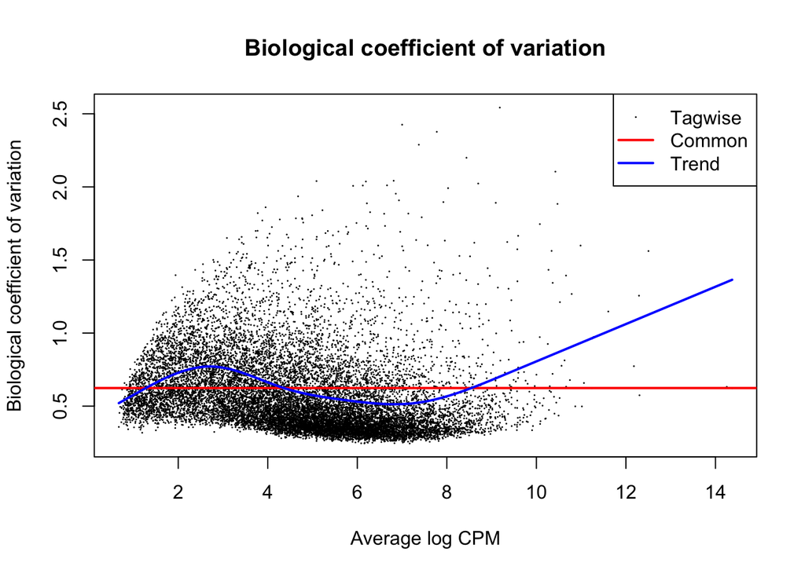

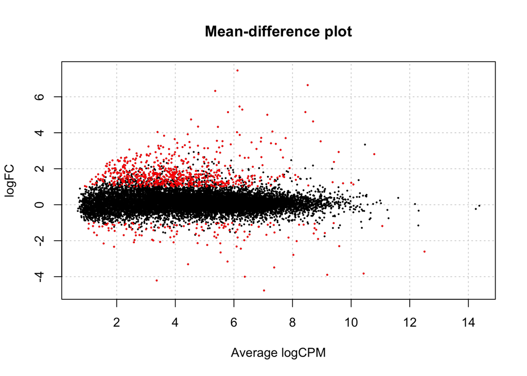

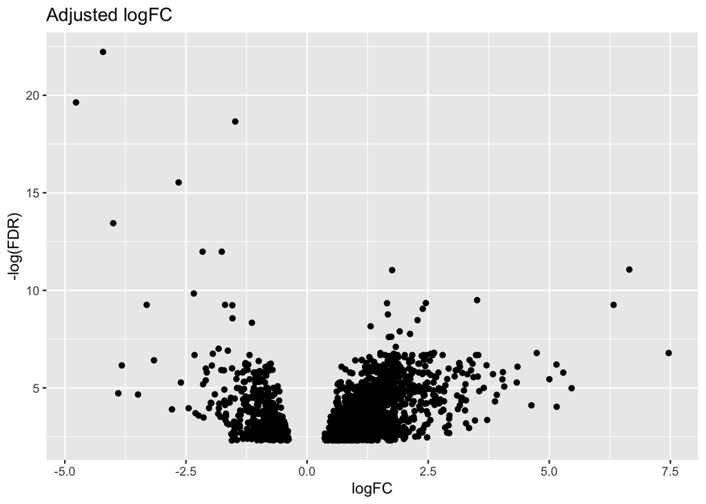

## Step 2: PCSF file prep - Create score file and format STRING interaction data

- Convert gene ensembl to gene symbol
- Create score file from logFC values
- Feed list of proteins into STRING/Cytoscape
- Format output and create interaction file

```r
## convert to gene names and create list for STRING

# read in the data
kylie_data <- read.csv("intermediate/edgeR/edgeR_dif_exp_genes.csv")

# subset the gene_id and logFC columns
kylie_data <- subset(kylie_data, select = c("gene_id", "logFC"))

# convert to gene symbol
gene_id <- getBM(attributes = c("ensembl_gene_id", "external_gene_name"),
                       filters = "ensembl_gene_id",
                       values = kylie_data$gene_id,
                       mart = ensembl)

# remove empty rows
gene_id <- subset(gene_id, external_gene_name != "") # uniprot_gn_symbol = 772

# check for duplicate uniprot ids
gene_id <- distinct(gene_id)

# merge back with original data
colnames(gene_id)[1] <- "gene_id"

kylie_gene_data <- merge(gene_id, kylie_data, by = "gene_id")

kylie_gene_data <- subset(kylie_gene_data, select = c("external_gene_name", "logFC"))

# check to see if genes that at all genes were converted at least once
missing_genes <- anti_join(kylie_data, gene_id, by = "gene_id")

# create score file
write.csv(kylie_gene_data, "intermediate/PCSF_data/pcsf_kylie_score.csv")

## create ensemble protein list for interaction db
write.table(kylie_gene_data$external_gene_name, "intermediate/cytoscape/kylie_gene_list.txt", row.names = F, col.names = F, quote = F)
```

```r
string_edge_data <- read.table("intermediate/cytoscape/STRING network (physical) default edge.csv", header = T, sep = ",", stringsAsFactors = F)
ppi_list <- subset(string_edge_data, select = c("name", "stringdb..score"))
ppi_list <- ppi_list %>%
  separate(name, sep = " ", into = c("node_1", "del", "node_2"))
ppi_list <- subset(ppi_list, select = c("node_1", "node_2", "stringdb..score"))
ppi_list$node_1 <- gsub(".*.\\.", "", ppi_list$node_1)
ppi_list$node_2 <- gsub(".*.\\.", "", ppi_list$node_2)

string_node_data <- read.table("intermediate/cytoscape/STRING network (physical) default node.csv", header = T, sep = ",", stringsAsFactors = F)
node_list <- subset(string_node_data, select = c("name", "query.term"))
node_list$name <- gsub(".*.\\.", "", node_list$name)
ppi_list$original_order <- seq_len(nrow(ppi_list))
merged_df <- merge(ppi_list, node_list, by.x = "node_1", by.y = "name", all.x = TRUE)
merged_df <- merge(merged_df, node_list, by.x = "node_2", by.y = "name", all.x = TRUE)
merged_df <- merged_df[order(merged_df$original_order), ]

final_df <- merged_df[, c("query.term.x", "query.term.y", "stringdb..score")]
colnames(final_df) <- c("node_1", "node_2", "score")

write.csv(final_df, "intermediate/PCSF_data/STRING_data.csv")


# create gene_id uniprot_id ref list.
ref_list <- getBM(attributes = c("external_gene_name","uniprot_gn_id"),
                  filters = "external_gene_name",
                  values = node_list$query.term,
                  mart = ensembl)
```

## Step 3: Run PCSF and create cross reference results with AF structures for durggability

```
##   45.42% of your terminal nodes are included in the interactome
##   Solving the PCSF by adding random noise to the edge costs...
```

```
## Time difference of 2.836514 secs
```

[interactive chart not shown]

PCSF Nertwork Metrics

|  | gene_id | cluster | betweenness | degree_centrality |
| --- | --- | --- | --- | --- |
| 1 | A4GALT | 1 | 0 | 1 |
| 115 | GLA | 1 | 0 | 1 |
| 12 | ATAD5 | 2 | 0 | 1 |
| 22 | BOP1 | 2 | 0 | 1 |
| 23 | BRAT1 | 2 | 0 | 1 |
| 28 | C4B | 2 | 0 | 1 |
| 34 | CCNE2 | 2 | 0 | 1 |
| 39 | CDC25C | 2 | 0 | 1 |
| 44 | CDCA5 | 2 | 0 | 1 |
| 47 | CDH3 | 2 | 0 | 1 |
| 49 | CDKN3 | 2 | 0 | 1 |
| 52 | CENPE | 2 | 0 | 1 |
| 60 | CHAF1B | 2 | 0 | 1 |
| 63 | CIT | 2 | 0 | 1 |
| 64 | CKS2 | 2 | 0 | 1 |
| 74 | DEPDC1 | 2 | 0 | 1 |
| 75 | DEPDC1B | 2 | 0 | 1 |
| 80 | DNAH9 | 2 | 0 | 1 |
| 81 | DNM1 | 2 | 0 | 1 |
| 83 | DSCC1 | 2 | 0 | 1 |
| 86 | E2F2 | 2 | 0 | 1 |
| 88 | E2F8 | 2 | 0 | 1 |
| 89 | EME1 | 2 | 0 | 1 |
| 90 | ENO1 | 2 | 0 | 1 |
| 93 | ERCC6L | 2 | 0 | 1 |
| 94 | ESPL1 | 2 | 0 | 1 |
| 95 | ESPN | 2 | 0 | 1 |
| 97 | FABP1 | 2 | 0 | 1 |
| 99 | FANCA | 2 | 0 | 1 |
| 100 | FANCB | 2 | 0 | 1 |

[output cut: 288 more lines]

## Step 4: Combine Structural and Citation data

Note: The citation scores for this data were generated using PubMed API

**Show raw table**

PCSF Druggability Results

| external_gene_name | uniprot_gn_id | cluster | betweenness | degree_centrality | file_id | ID | pocket | druggability | num_drug_pockets | struct_score | logFC | regulation | citation_score |
| --- | --- | --- | --- | --- | --- | --- | --- | --- | --- | --- | --- | --- | --- |
| MUC17 | Q685J3 | 3 | 0 | 1 | AF-Q685J3-F5-model_v4 | Q685J3-F5 | 0.317 | 1.000 | 7 | 50.38741 | 2.932704 | up_reg | 99 |
| MUC17 | Q685J3 | 3 | 0 | 1 | AF-Q685J3-F12-model_v4 | Q685J3-F12 | 0.130 | 1.000 | 3 | 55.24057 | 2.932704 | up_reg | 99 |
| MUC17 | Q685J3 | 3 | 0 | 1 | AF-Q685J3-F3-model_v4 | Q685J3-F3 | 0.321 | 1.000 | 5 | 57.04810 | 2.932704 | up_reg | 99 |
| MUC17 | Q685J3 | 3 | 0 | 1 | AF-Q685J3-F2-model_v4 | Q685J3-F2 | 0.338 | 0.999 | 8 | 53.74200 | 2.932704 | up_reg | 99 |
| MUC17 | Q685J3 | 3 | 0 | 1 | AF-Q685J3-F10-model_v4 | Q685J3-F10 | 0.303 | 0.998 | 8 | 57.31370 | 2.932704 | up_reg | 99 |
| MUC17 | Q685J3 | 3 | 0 | 1 | AF-Q685J3-F11-model_v4 | Q685J3-F11 | 0.223 | 0.998 | 4 | 55.80117 | 2.932704 | up_reg | 99 |
| MUC17 | Q685J3 | 3 | 0 | 1 | AF-Q685J3-F13-model_v4 | Q685J3-F13 | 0.184 | 0.998 | 9 | 52.17108 | 2.932704 | up_reg | 99 |
| CENPE | Q02224 | 2 | 0 | 1 | AF-Q02224-F6-model_v4 | Q02224-F6 | 0.135 | 0.997 | 5 | 72.55249 | 1.272231 | up_reg | 439 |
| MUC17 | Q685J3 | 3 | 0 | 1 | AF-Q685J3-F7-model_v4 | Q685J3-F7 | 0.253 | 0.996 | 7 | 51.47074 | 2.932704 | up_reg | 99 |
| MUC17 | Q685J3 | 3 | 0 | 1 | AF-Q685J3-F1-model_v4 | Q685J3-F1 | 0.162 | 0.996 | 6 | 51.86692 | 2.932704 | up_reg | 99 |
| CD9 | P21926 | 3 | 194 | 6 | AF-P21926-F1-model_v4 | P21926-F1 | 0.063 | 0.994 | 1 | 88.11915 | 1.203438 | up_reg | 2729 |
| MELK | Q14680 | 2 | 0 | 1 | AF-Q14680-F1-model_v4 | Q14680-F1 | 0.159 | 0.993 | 1 | 70.64372 | 1.755936 | up_reg | 669 |
| MUC17 | Q685J3 | 3 | 0 | 1 | AF-Q685J3-F6-model_v4 | Q685J3-F6 | 0.273 | 0.993 | 5 | 57.70932 | 2.932704 | up_reg | 99 |
| MUC17 | Q685J3 | 3 | 0 | 1 | AF-Q685J3-F17-model_v4 | Q685J3-F17 | 0.018 | 0.993 | 2 | 52.40577 | 2.932704 | up_reg | 99 |
| XPR1 | Q9UBH6 | 2 | 0 | 1 | AF-Q9UBH6-F1-model_v4 | Q9UBH6-F1 | 0.207 | 0.993 | 3 | 83.73372 | 1.318176 | up_reg | 180 |
| KIF11 | P52732 | 2 | 48 | 4 | AF-P52732-F1-model_v4 | P52732-F1 | 0.141 | 0.991 | 1 | 74.76864 | 1.239185 | up_reg | 827 |
| PTGS2 | P35354 | 2 | 260 | 2 | AF-P35354-F1-model_v4 | P35354-F1 | 0.262 | 0.987 | 1 | 93.32770 | 2.338946 | up_reg | 41309 |
| TEAD4 | Q15561 | 2 | 0 | 1 | AF-Q15561-F1-model_v4 | Q15561-F1 | 0.243 | 0.986 | 2 | 76.58312 | 1.597999 | up_reg | 388 |
| FABP1 | P07148 | 2 | 0 | 1 | AF-P07148-F1-model_v4 | P07148-F1 | -0.023 | 0.981 | 1 | 94.95010 | 7.464763 | up_reg | 900 |
| ABCA2 | Q9BZC7 | 2 | 3430 | 2 | AF-Q9BZC7-F1-model_v4 | Q9BZC7-F1 | 0.258 | 0.976 | 5 | 72.33891 | 1.262028 | up_reg | 138 |
| PRC1 | O43663 | 2 | 0 | 1 | AF-O43663-F1-model_v4 | O43663-F1 | 0.226 | 0.975 | 2 | 80.11427 | 1.458330 | up_reg | 1534 |
| SPAG4 | Q9NPE6 | 2 | 0 | 1 | AF-Q9NPE6-F1-model_v4 | Q9NPE6-F1 | 0.378 | 0.975 | 1 | 71.56424 | 1.521158 | up_reg | 51 |
| KIF20B | Q96Q89 | 2 | 0 | 2 | AF-Q96Q89-F1-model_v4 | Q96Q89-F1 | 0.232 | 0.971 | 4 | 63.74834 | 1.021659 | up_reg | 57 |
| H2BC10 | P62807 | 2 | 288 | 12 | AF-P62807-F1-model_v4 | P62807-F1 | 0.291 | 0.965 | 1 | 87.82973 | 1.200574 | up_reg | 0 |
| H2BC4 | P62807 | 2 | 213 | 9 | AF-P62807-F1-model_v4 | P62807-F1 | 0.291 | 0.965 | 1 | 87.82973 | 1.124252 | up_reg | 0 |
| H2BC6 | P62807 | 2 | 4200 | 13 | AF-P62807-F1-model_v4 | P62807-F1 | 0.291 | 0.965 | 1 | 87.82973 | 1.513907 | up_reg | 0 |
| H2BC7 | P62807 | 2 | 2530 | 12 | AF-P62807-F1-model_v4 | P62807-F1 | 0.291 | 0.965 | 1 | 87.82973 | 1.650740 | up_reg | 0 |
| H2BC8 | P62807 | 2 | 801 | 12 | AF-P62807-F1-model_v4 | P62807-F1 | 0.291 | 0.965 | 1 | 87.82973 | 1.316050 | up_reg | 1 |
| CENPE | Q02224 | 2 | 0 | 1 | AF-Q02224-F2-model_v4 | Q02224-F2 | 0.126 | 0.960 | 2 | 70.76444 | 1.272231 | up_reg | 439 |
| DNAH3 | Q8TD57 | 7 | 0 | 1 | AF-Q8TD57-F4-model_v4 | Q8TD57-F4 | 0.164 | 0.960 | 4 | 85.66639 | 2.305663 | up_reg | 16 |

[output cut: 390 more lines]

PCSF Druggability Results

| external_gene_name | uniprot_gn_id | cluster | betweenness | degree_centrality | file_id | ID | pocket | druggability | num_drug_pockets | struct_score | logFC | regulation | citation_score |
| --- | --- | --- | --- | --- | --- | --- | --- | --- | --- | --- | --- | --- | --- |
| MUC17 | Q685J3 | 3 | 0 | 1 | AF-Q685J3-F5-model_v4 | Q685J3-F5 | 0.317 | 1.000 | 7 | 50.38741 | 2.932704 | up_reg | 99 |
| CENPE | Q02224 | 2 | 0 | 1 | AF-Q02224-F6-model_v4 | Q02224-F6 | 0.135 | 0.997 | 5 | 72.55249 | 1.272231 | up_reg | 439 |
| CD9 | P21926 | 3 | 194 | 6 | AF-P21926-F1-model_v4 | P21926-F1 | 0.063 | 0.994 | 1 | 88.11915 | 1.203438 | up_reg | 2729 |
| MELK | Q14680 | 2 | 0 | 1 | AF-Q14680-F1-model_v4 | Q14680-F1 | 0.159 | 0.993 | 1 | 70.64372 | 1.755936 | up_reg | 669 |
| XPR1 | Q9UBH6 | 2 | 0 | 1 | AF-Q9UBH6-F1-model_v4 | Q9UBH6-F1 | 0.207 | 0.993 | 3 | 83.73372 | 1.318176 | up_reg | 180 |
| KIF11 | P52732 | 2 | 48 | 4 | AF-P52732-F1-model_v4 | P52732-F1 | 0.141 | 0.991 | 1 | 74.76864 | 1.239185 | up_reg | 827 |
| PTGS2 | P35354 | 2 | 260 | 2 | AF-P35354-F1-model_v4 | P35354-F1 | 0.262 | 0.987 | 1 | 93.32770 | 2.338946 | up_reg | 41309 |
| TEAD4 | Q15561 | 2 | 0 | 1 | AF-Q15561-F1-model_v4 | Q15561-F1 | 0.243 | 0.986 | 2 | 76.58312 | 1.597999 | up_reg | 388 |
| FABP1 | P07148 | 2 | 0 | 1 | AF-P07148-F1-model_v4 | P07148-F1 | -0.023 | 0.981 | 1 | 94.95010 | 7.464763 | up_reg | 900 |
| ABCA2 | Q9BZC7 | 2 | 3430 | 2 | AF-Q9BZC7-F1-model_v4 | Q9BZC7-F1 | 0.258 | 0.976 | 5 | 72.33891 | 1.262028 | up_reg | 138 |
| PRC1 | O43663 | 2 | 0 | 1 | AF-O43663-F1-model_v4 | O43663-F1 | 0.226 | 0.975 | 2 | 80.11427 | 1.458330 | up_reg | 1534 |
| SPAG4 | Q9NPE6 | 2 | 0 | 1 | AF-Q9NPE6-F1-model_v4 | Q9NPE6-F1 | 0.378 | 0.975 | 1 | 71.56424 | 1.521158 | up_reg | 51 |
| KIF20B | Q96Q89 | 2 | 0 | 2 | AF-Q96Q89-F1-model_v4 | Q96Q89-F1 | 0.232 | 0.971 | 4 | 63.74834 | 1.021659 | up_reg | 57 |
| H2BC10 | P62807 | 2 | 288 | 12 | AF-P62807-F1-model_v4 | P62807-F1 | 0.291 | 0.965 | 1 | 87.82973 | 1.200574 | up_reg | 0 |
| H2BC4 | P62807 | 2 | 213 | 9 | AF-P62807-F1-model_v4 | P62807-F1 | 0.291 | 0.965 | 1 | 87.82973 | 1.124252 | up_reg | 0 |
| H2BC6 | P62807 | 2 | 4200 | 13 | AF-P62807-F1-model_v4 | P62807-F1 | 0.291 | 0.965 | 1 | 87.82973 | 1.513907 | up_reg | 0 |
| H2BC7 | P62807 | 2 | 2530 | 12 | AF-P62807-F1-model_v4 | P62807-F1 | 0.291 | 0.965 | 1 | 87.82973 | 1.650740 | up_reg | 0 |
| H2BC8 | P62807 | 2 | 801 | 12 | AF-P62807-F1-model_v4 | P62807-F1 | 0.291 | 0.965 | 1 | 87.82973 | 1.316050 | up_reg | 1 |
| DNAH3 | Q8TD57 | 7 | 0 | 1 | AF-Q8TD57-F4-model_v4 | Q8TD57-F4 | 0.164 | 0.960 | 4 | 85.66639 | 2.305663 | up_reg | 16 |
| RARA | P10276 | 2 | 5107 | 16 | AF-P10276-F1-model_v4 | P10276-F1 | 0.362 | 0.958 | 1 | 79.41892 | 1.490980 | up_reg | 4411 |
| CYBA | P13498 | 2 | 1284 | 3 | AF-P13498-F1-model_v4 | P13498-F1 | 0.480 | 0.957 | 1 | 77.02989 | 1.275871 | up_reg | 1045 |
| H2BC17 | P23527 | 2 | 260 | 9 | AF-P23527-F1-model_v4 | P23527-F1 | 0.371 | 0.957 | 2 | 88.00099 | 1.844521 | up_reg | 0 |
| TTK | P33981 | 2 | 1031 | 4 | AF-P33981-F1-model_v4 | P33981-F1 | 0.087 | 0.956 | 1 | 63.95435 | 1.457472 | up_reg | 2071 |
| SLC19A3 | Q9BZV2 | 3 | 0 | 1 | AF-Q9BZV2-F1-model_v4 | Q9BZV2-F1 | 0.137 | 0.955 | 2 | 82.16840 | 3.205348 | up_reg | 180 |
| FZD7 | O75084 | 2 | 776 | 4 | AF-O75084-F1-model_v4 | O75084-F1 | 0.435 | 0.953 | 3 | 84.14906 | 1.548584 | up_reg | 390 |
| PLK1 | P53350 | 2 | 2733 | 10 | AF-P53350-F1-model_v4 | P53350-F1 | 0.175 | 0.953 | 2 | 85.16989 | 1.603519 | up_reg | 3003 |
| IL32 | P24001 | 2 | 0 | 1 | AF-P24001-F1-model_v4 | P24001-F1 | 0.099 | 0.950 | 2 | 71.19002 | 1.544145 | up_reg | 628 |
| ASPM | Q8IZT6 | 2 | 639 | 4 | AF-Q8IZT6-F10-model_v4 | Q8IZT6-F10 | 0.434 | 0.949 | 4 | 62.64048 | 1.477836 | up_reg | 518 |
| LAMA5 | O15230 | 5 | 3 | 2 | AF-O15230-F12-model_v4 | O15230-F12 | 0.086 | 0.946 | 2 | 79.24314 | 2.198114 | up_reg | 155 |
| PDE3A | Q14432 | 2 | 0 | 1 | AF-Q14432-F1-model_v4 | Q14432-F1 | 0.272 | 0.945 | 3 | 61.48643 | 1.816074 | up_reg | 371 |

[output cut: 272 more lines]

## Step 5: Functional Enrichment Analysis

```
##   Performing enrichment analysis...
```

```
##   Enrichment is being performed by EnrichR (http://amp.pharm.mssm.edu/Enrichr) API ...
## [1] "Number of enrichment results: 27"
```

#### Tip: Hover over nodes for details!

[interactive chart not shown]

Note: P-value represents likelihood of observing that pathway by random chance. The top 15 functional enrichment terms for each cluster are ranked according to the adjusted p-value. This is what you observe when you hover your mouse over a node in that cluster.

**Tabulated format**

Enrichment Results

| Cluster | Term | PValue | Adjusted_Pvalue | Genes |
| --- | --- | --- | --- | --- |
| 2 | regulation of cellular component size (GO:0032535) | 2.853203205375592E-4 | 0.009653337511520754 | NEB;IQGAP3;CIT |
| 2 | chromosome organization (GO:0051276) | 5.309166049096651E-4 | 0.012679537740783767 | NCAPG;NCAPH;CIT |
| 2 | regulation of anatomical structure size (GO:0090066) | 7.716824091518915E-4 | 0.014241048096166725 | NEB;IQGAP3;CIT |
| 2 | regulation of actin filament-based process (GO:0032970) | 0.0010375794448162583 | 0.01734785921116683 | NEB;ATP1A1;CIT |
| 2 | actin filament-based process (GO:0030029) | 0.0016655778410991028 | 0.02600863859562445 | TMOD1;BCL6;NEB |
| 2 | spermatogenesis (GO:0007283) | 0.002573726987660608 | 0.03291716539476697 | BCL6;DNAH9;CIT |
| 2 | male gamete generation (GO:0048232) | 0.002594456385794441 | 0.03291716539476697 | BCL6;DNAH9;CIT |
| 2 | ATP metabolic process (GO:0046034) | 0.0031003034101407144 | 0.03702127013285677 | ABCA2;DNAH9;ATP1A1 |
| 2 | gamete generation (GO:0007276) | 0.0034113793392660454 | 0.03957200033548613 | BCL6;DNAH9;CIT |
| 2 | purine ribonucleoside monophosphate metabolic process (GO:0009167) | 0.0037150696836296742 | 0.03997073687603469 | ABCA2;DNAH9;ATP1A1 |
| 2 | purine nucleoside monophosphate metabolic process (GO:0009126) | 0.003741103451451523 | 0.03997073687603469 | ABCA2;DNAH9;ATP1A1 |
| 2 | ribonucleoside monophosphate metabolic process (GO:0009161) | 0.004089837030204999 | 0.04257625216059563 | ABCA2;DNAH9;ATP1A1 |
| 2 | nucleoside monophosphate metabolic process (GO:0009123) | 0.004400024649679723 | 0.04308207656959098 | ABCA2;DNAH9;ATP1A1 |
| 2 | multicellular organismal reproductive process (GO:0048609) | 0.00648969504452812 | 0.04626047591773712 | BCL6;DNAH9;CIT |
| 2 | Protein digestion and absorption Homo sapiens hsa04974 | 4.729605552859509E-5 | 0.0011351053326862821 | SLC3A1;ATP1B3;ATP1A1 |
| 2 | Muscle contraction Homo sapiens R-HSA-397014 | 1.4845023306409954E-5 | 4.601957224987086E-4 | TMOD1;ATP1B3;NEB;ATP1A1 |
| 2 | Transmembrane transport of small molecules Homo sapiens R-HSA-382551 | 7.56156661616401E-5 | 7.813618836702811E-4 | ABCA2;SLC7A5;SLC3A1;ATP1B3;ATP1A1 |
| 3 | calcium-independent cell-cell adhesion via plasma membrane cell-adhesion molecules (GO:0016338) | 4.142160251914031E-11 | 1.8184083505902596E-8 | CLDN4;CLDN3;CLDN15;CLDN7;CLDN2 |
| 3 | cell-cell adhesion via plasma-membrane adhesion molecules (GO:0098742) | 7.928270709188758E-8 | 1.196869036310753E-5 | CLDN4;CLDN3;CLDN15;CLDN7;CLDN2;ICAM1 |
| 3 | cell-cell adhesion (GO:0098609) | 8.179059473649792E-8 | 1.196869036310753E-5 | CLDN4;CLDN3;CLDN15;CLDN7;CLDN2;ICAM1 |
| 3 | peptide metabolic process (GO:0006518) | 3.2596951610233536E-4 | 0.0251555384035891 | MME;ANPEP;GGT1 |
| 3 | cellular amide metabolic process (GO:0043603) | 0.0012028947887501064 | 0.05867453469569964 | MME;ANPEP;GGT1 |
| 3 | protein processing (GO:0016485) | 0.0017321782940624465 | 0.07347362074129819 | MME;ANPEP;GGT1 |
| 3 | protein maturation (GO:0051604) | 0.002298885816114334 | 0.07347362074129819 | MME;ANPEP;GGT1 |
| 3 | regulation of hormone levels (GO:0010817) | 0.0025104881802265897 | 0.07347362074129819 | ABCC2;MME;ANPEP |
| 3 | response to hypoxia (GO:0001666) | 0.0029006543391088256 | 0.07846639217384778 | DPP4;CLDN3;ICAM1 |
| 3 | response to decreased oxygen levels (GO:0036293) | 0.0030385618837253125 | 0.07846639217384778 | DPP4;CLDN3;ICAM1 |
| 3 | response to oxygen levels (GO:0070482) | 0.0035529211756350197 | 0.08665179978354298 | DPP4;CLDN3;ICAM1 |
| 3 | response to acid chemical (GO:0001101) | 0.004202671713238798 | 0.08821989685703478 | ABCC2;CD9;ICAM1 |
| 3 | regulation of cell adhesion (GO:0030155) | 0.007322050378773087 | 0.11084069366487534 | DPP4;PODXL;ICAM1 |

[output cut: 900 more lines]

## Weighted Gene Ranking

In this table the genes are ordered by their combined rank score which is a normalised score with the following contributions:

- Betweeness: 10%
- Citation score: 20%
- Degree centrality: 30%
- Druggability: 40%

Ordered by Combined Rank Score

| external_gene_name | uniprot_gn_id | cluster | betweenness | degree_centrality | file_id | ID | pocket | druggability | num_drug_pockets | struct_score | logFC | regulation | citation_score | combined_score |
| --- | --- | --- | --- | --- | --- | --- | --- | --- | --- | --- | --- | --- | --- | --- |
| H2BC13 | Q99880 | 2 | 1475 | 19 | AF-Q99880-F1-model_v4 | Q99880-F1 | 0.414 | 0.944 | 2 | 87.44870 | 1.723938 | up_reg | 0 | 0.6857062 |
| H2BC15 | Q99877 | 2 | 1247 | 18 | AF-Q99877-F1-model_v4 | Q99877-F1 | 0.313 | 0.935 | 1 | 87.69131 | 1.134114 | up_reg | 0 | 0.6641865 |
| H2BC6 | P62807 | 2 | 4200 | 13 | AF-P62807-F1-model_v4 | P62807-F1 | 0.291 | 0.965 | 1 | 87.82973 | 1.513907 | up_reg | 0 | 0.6090820 |
| H2BC7 | P62807 | 2 | 2530 | 12 | AF-P62807-F1-model_v4 | P62807-F1 | 0.291 | 0.965 | 1 | 87.82973 | 1.650740 | up_reg | 0 | 0.5832375 |
| H2BC10 | P62807 | 2 | 288 | 12 | AF-P62807-F1-model_v4 | P62807-F1 | 0.291 | 0.965 | 1 | 87.82973 | 1.200574 | up_reg | 0 | 0.5709161 |
| H2BC14 | Q99879 | 2 | 766 | 14 | AF-Q99879-F1-model_v4 | Q99879-F1 | 0.365 | 0.888 | 2 | 86.12243 | 1.594661 | up_reg | 1 | 0.5630336 |
| H2BC8 | P62807 | 2 | 801 | 12 | AF-P62807-F1-model_v4 | P62807-F1 | 0.291 | 0.965 | 1 | 87.82973 | 1.316050 | up_reg | 1 | 0.5606927 |
| H2BC3 | P33778 | 2 | 269 | 11 | AF-P33778-F1-model_v4 | P33778-F1 | 0.423 | 0.941 | 2 | 87.64271 | 1.429227 | up_reg | 2 | 0.5238728 |
| H2BC4 | P62807 | 2 | 213 | 9 | AF-P62807-F1-model_v4 | P62807-F1 | 0.291 | 0.965 | 1 | 87.82973 | 1.124252 | up_reg | 0 | 0.5205039 |
| H2BC17 | P23527 | 2 | 260 | 9 | AF-P23527-F1-model_v4 | P23527-F1 | 0.371 | 0.957 | 2 | 88.00099 | 1.844521 | up_reg | 0 | 0.5175622 |
| RARA | P10276 | 2 | 5107 | 16 | AF-P10276-F1-model_v4 | P10276-F1 | 0.362 | 0.958 | 1 | 79.41892 | 1.490980 | up_reg | 4411 | 0.5033553 |
| NR5A2 | O00482 | 2 | 5443 | 14 | AF-O00482-F1-model_v4 | O00482-F1 | 0.203 | 0.936 | 2 | 72.86144 | 1.943734 | up_reg | 569 | 0.5015759 |
| H2BC12 | O60814 | 2 | 20 | 10 | AF-O60814-F1-model_v4 | O60814-F1 | 0.241 | 0.937 | 1 | 88.05779 | 1.128966 | up_reg | 3 | 0.4988244 |
| H2BC11 | P06899 | 2 | 233 | 10 | AF-P06899-F1-model_v4 | P06899-F1 | 0.250 | 0.870 | 2 | 85.69804 | 1.482316 | up_reg | 1 | 0.4862378 |
| CENPI | Q92674 | 2 | 1240 | 10 | AF-Q92674-F1-model_v4 | Q92674-F1 | 0.058 | 0.915 | 3 | 72.79816 | 1.176172 | up_reg | 68 | 0.4431428 |
| H2BC18 | Q5QNW6 | 2 | 34 | 7 | AF-Q5QNW6-F1-model_v4 | Q5QNW6-F1 | 0.422 | 0.825 | 2 | 87.95688 | 1.297057 | up_reg | 0 | 0.4301869 |
| H3C1 | P68431 | 2 | 1350 | 12 | AF-P68431-F1-model_v4 | P68431-F1 | 0.351 | 0.623 | 1 | 87.28692 | 1.099690 | up_reg | 5 | 0.4062376 |
| ORC1 | Q13415 | 2 | 15590 | 8 | AF-Q13415-F1-model_v4 | Q13415-F1 | 0.154 | 0.765 | 1 | 67.97461 | 1.802587 | up_reg | 378 | 0.3966200 |
| PLK1 | P53350 | 2 | 2733 | 10 | AF-P53350-F1-model_v4 | P53350-F1 | 0.175 | 0.953 | 2 | 85.16989 | 1.603519 | up_reg | 3003 | 0.3955413 |
| PHF19 | Q5T6S3 | 2 | 430 | 11 | AF-Q5T6S3-F1-model_v4 | Q5T6S3-F1 | 0.257 | 0.765 | 1 | 69.88708 | 1.211096 | up_reg | 70 | 0.3948203 |
| H3C12 | P68431 | 2 | 4161 | 8 | AF-P68431-F1-model_v4 | P68431-F1 | 0.351 | 0.623 | 1 | 87.28692 | 2.005020 | up_reg | 0 | 0.3887343 |
| H4C1 | P62805 | 2 | 847 | 10 | AF-P62805-F1-model_v4 | P62805-F1 | 0.336 | 0.581 | 1 | 90.43752 | 1.351587 | up_reg | 1 | 0.3740121 |
| CDK1 | P06493 | 2 | 18044 | 16 | AF-P06493-F1-model_v4 | P06493-F1 | 0.514 | 0.471 | 1 | 89.31551 | 1.580437 | up_reg | 6002 | 0.3738591 |
| TOP2A | P11388 | 2 | 1844 | 9 | AF-P11388-F1-model_v4 | P11388-F1 | 0.045 | 0.897 | 1 | 76.40832 | 2.033427 | up_reg | 1351 | 0.3666115 |
| UBE2S | Q16763 | 2 | 18196 | 9 | AF-Q16763-F1-model_v4 | Q16763-F1 | 0.168 | 0.552 | 1 | 81.85029 | 2.280124 | up_reg | 119 | 0.3640486 |
| WDR76 | Q9H967 | 2 | 4995 | 4 | AF-Q9H967-F1-model_v4 | Q9H967-F1 | 0.272 | 0.861 | 1 | 75.38044 | 1.087175 | up_reg | 22 | 0.3628515 |
| RAC3 | P60763 | 2 | 2787 | 5 | AF-P60763-F1-model_v4 | P60763-F1 | 0.341 | 0.937 | 1 | 93.83371 | 1.213210 | up_reg | 301 | 0.3493319 |
| CCNB1 | P14635 | 2 | 2056 | 13 | AF-P14635-F1-model_v4 | P14635-F1 | 0.078 | 0.699 | 1 | 77.77241 | 1.801033 | up_reg | 2303 | 0.3452128 |
| SPAG5 | Q96R06 | 2 | 1766 | 5 | AF-Q96R06-F1-model_v4 | Q96R06-F1 | 0.223 | 0.887 | 2 | 63.81311 | 1.534844 | up_reg | 127 | 0.3398729 |
| H2AC14 | Q99878 | 2 | 5614 | 14 | AF-Q99878-F1-model_v4 | Q99878-F1 | 0.443 | 0.230 | 0 | 91.90550 | 1.611322 | up_reg | 0 | 0.3395196 |

[output cut: 272 more lines]

### Gene subset progression

```
## Raw gene list = 14889 --> Initial subset (>1 in >=0.5) = 14868
```

```
## Initial subset = 14868 --> EdgeR hits (only dif exp genes) = 790
```

```
## EdgeR hits = 790 --> ensembl gene converted = 764
```

```
## ensembl gene converted = 764 --> Cytoscape/STRING = 718
```

```
## Cytoscape/STRING = 718 --> PCSF subnet = 318
```

```
## PCSF subnet = 318 --> Druggability CrossRef = 420
```

```
## Druggability CrossRef = 420 --> Unique IDs = 302
```

end of doc